# Predicting the Capture Rate of Pokemon

PSTAT 131 Final Project

Shivani Kharva

2022-12-06

# Introduction

The purpose of this project is to develop a model that will predict the capture rate of a Pokemon.

## What Are Pokemon?

Pokemon (or “pocket monsters”) are creatures from the Japanese Nintendo video game, Pokemon. Pokemon is a role-playing game in which players play as trainers who capture the Pokemon using Poke Balls and train them to compete in battles with other trainers. As they train and gain more experience through battle, Pokemon evolve and grow stronger. There are over 800 Pokemon with 18 types (i.e. fire, water, etc,), and they have numerous abilities (both common and unique).

## What Are We Trying to Do?

However, a question I’d like to pose is “How hard is to capture a Pokemon in the first place depending on their existing statistics?” It seems quite reasonable to hypothesize that a Pokemon’s capture rate would vary depending on variables like their type, base statistics, generation, etc. So, I would like to test if it is possible to develop a model that can predict the capture rate of a Pokemon based on those qualities.

## Why?

Players, including me, are often only able to see the aforementioned qualities of a Pokemon and not their actual capture rate. So, it may be useful to have a specific model that can accurately predict the capture rate of a Pokemon so a player may see how difficult it may be to capture that Pokemon. The player can then adjust their strategy if a Pokemon is harder to catch by using more advanced equipment, such as using an Ultra Ball instead of a Poke Ball or giving the Pokemon a fruit before attempting to capture them to slightly lower their guard. So, let’s see if the variation in the capture rate of a specific Pokemon can be explained by these qualities!

# Loading Packages and Data

First, let’s load in all of our packages and the raw Pokemon data.

```r
# Loading all necessary packages
library(tidyverse)
library(dplyr)
library(tidymodels)
library(readr)
library(kknn)
library(janitor)
library(ISLR)
library(discrim)
library(poissonreg)
library(glmnet)
library(corrr)
library(corrplot)
library(randomForest)
library(xgboost)
library(rpart.plot)
library(vip)
library(ranger)
library(tidytext)

# Assigning the data to a variable
pokemon <- read_csv("data/pokemon.csv")
tidymodels_prefer()
set.seed(0124)

# Calling head() to see the first few rows
head(pokemon)
```

```
## # A tibble: 6 × 41
##   abilities      again…¹ again…² again…³ again…⁴ again…⁵ again…⁶ again…⁷ again…⁸
##   <chr>            <dbl>   <dbl>   <dbl>   <dbl>   <dbl>   <dbl>   <dbl>   <dbl>
## 1 ['Overgrow', …    1          1       1     0.5     0.5     0.5     2         2
## 2 ['Overgrow', …    1          1       1     0.5     0.5     0.5     2         2
## 3 ['Overgrow', …    1          1       1     0.5     0.5     0.5     2         2
## 4 ['Blaze', 'So…    0.5        1       1     1       0.5     1       0.5       1
## 5 ['Blaze', 'So…    0.5        1       1     1       0.5     1       0.5       1
## 6 ['Blaze', 'So…    0.25       1       1     2       0.5     0.5     0.5       1
## # … with 32 more variables: against_ghost <dbl>, against_grass <dbl>,
## #   against_ground <dbl>, against_ice <dbl>, against_normal <dbl>,
## #   against_poison <dbl>, against_psychic <dbl>, against_rock <dbl>,
## #   against_steel <dbl>, against_water <dbl>, attack <dbl>,
## #   base_egg_steps <dbl>, base_happiness <dbl>, base_total <dbl>,
## #   capture_rate <chr>, classfication <chr>, defense <dbl>,
## #   experience_growth <dbl>, height_m <dbl>, hp <dbl>, japanese_name <chr>, …
```

This data was taken from the Kaggle data set, “[Pokemon Stats Dataset](https://www.kaggle.com/datasets/hasanarcas/pokemon-stats-dataset),” and it was scraped from the [official Pokemon database](https://pokemondb.net/pokedex/all) by user Hasan Arcas.

# Exploring and Tidying the Raw Data

## Variable Selection

Let’s mess around with the data a little bit to see what we’re currently working with!

```r
# Calling dim() to see how many rows and columns
dim(pokemon)
```

```
## [1] 801  41
```

The data set contains 801 rows and 41 columns. This means we have 801 Pokemon and 41 variables. One of those variables, `capture_rate`, is our response, but that leaves us with 40 predictor variables! We’re definitely going to have to narrow that down!

From the data, each of the variables that specify each Pokemon’s skill against a certain type of Pokemon (i.e. `against_bug`, `against_dark`, etc.) do not appear to be as relevant as other attributes in deciding whether specifc features about a Pokemon affect its capture rate. We can also assume that the `attack` variable gives us an overall estimate of each Pokemon’s attack skill so we would not need to go into such great detail as finding out how the Pokemon perform against every other type of Pokemon. For that reason, these 18 columns can be dropped.

At first, it seems that the `classification` variable may be helpful; however, let us see how many unique classifications of a Pokemon there are.

```r
# Checking how many unique classifications there are
pokemon %>%
  distinct(classfication) %>%
  count()
```

```
## # A tibble: 1 × 1
##       n
##   <int>
## 1   588
```

There are 588 unique classifications! That seems a little too high for our analysis so we will just stick to using the `type` of the Pokemon instead.

Furthermore, for the `abilities` variable, we can see that there is no set amount for how many abilities a Pokemon has or a measure to figure out which abilities are more powerful than others. For these reasons, it may be best to avoid including this column into our analysis.

The `base_egg_steps` variable is a variable not used in the original Pokemon games so, to keep the data consistent with the game it was taken from, this variable should also be omitted.

Finally, `pokedex_number` and `japanese_name` are unique to each Pokemon and are mainly used to identify the Pokemon; however, since we already have the `name` variable, it would not be useful to include these variables.

Now, let’s filter out all those unwanted variables and our dataset will be ready for further tidying!

```r
# Selecting only the variables we want
pokemon <- pokemon %>%
  select(c("abilities", "attack", "base_happiness",  "base_total", "capture_rate", "defense", "experience_growth", "height_m", "percentage_male", "hp", "name", "sp_attack", "sp_defense", "speed", "type1", "weight_kg", "generation", "is_legendary")) %>%
  clean_names()
```

## Tidying the Outcome

Upon further inspection, we can see that our outcome, `capture_rate`, is actually a character variable, which is not what we want. By looking into the values, we see that one of the Pokemon, Minior, actually has two capture rates.

```r
# Finding which Pokemon has a character capture rate
pokemon %>%
  filter(capture_rate %in% c("30 (Meteorite)255 (Core)")) %>%
  select(c(name, capture_rate))
```

```
## # A tibble: 1 × 2
##   name   capture_rate
##   <chr>  <chr>
## 1 Minior 30 (Meteorite)255 (Core)
```

By looking at Bulbapedia, a community Pokemon encyclopedia, we can see that Minior has a relatively low capture rate at 30 when it is “Meteorite,” meaning its shell has not been broken. However, once Minior’s shell is broken (“Core”), the Pokemon shoots up to a capture rate of 255, which is the highest capture rate there is. Therefore, it would make sense to keep the capture rate of Minior when it is still Meteorite.

```r
# Changing Minior to capture rate 30
pokemon[pokemon$name=="Minior", "capture_rate"] <- "30"

# Making capture_rate an integer
pokemon$capture_rate <- as.integer(pokemon$capture_rate)

# Displaying the new row
pokemon %>%
  filter(name %in% c("Minior")) %>%
  select(c(name, capture_rate))
```

```
## # A tibble: 1 × 2
##   name   capture_rate
##   <chr>         <int>
## 1 Minior           30
```

Now the capture rate for Minior is fixed and our outcome is an integer we can use in regression!

## Tidying the Abilities Variable

One last thing we need to do before our data is tidy the `abilities` variable because we currently have a column made up of lists of each Pokemon’s abilities. However, it is not very useful to analyze 801 unique lists of abilities. It might be better to prioritize the abilities that are the most common among the Pokemon. Let’s look at the top 5 most common abilities and their capture rates.

```r
# Creating a copy of the dataset to work with
pokemon_copy <- pokemon

# Splitting up the lists in the abilities column
pokemon_copy$abilities <- pokemon_copy$abilities %>%
  str_split(pattern = "', '") %>%
  map(~ str_replace_all(string = ., pattern = "[[:punct:]]", ""))

# Unnesting so the abilities are separate rows
pokemon_copy2 <- pokemon_copy %>%
  unnest()

# Viewing the top 5 abilities by count and their capture rates
pokemon_copy2 %>%
  group_by(abilities) %>%
  summarise(count = n(), capture_rate = mean(capture_rate)) %>%
  arrange(desc(count)) %>%
  head(5)
```

```
## # A tibble: 5 × 3
##   abilities   count capture_rate
##   <chr>       <int>        <dbl>
## 1 Sturdy         41        102.
## 2 Swift Swim     38        111.
## 3 Keen Eye       37        132.
## 4 Chlorophyll    35        124.
## 5 Levitate       33         85.0
```

The top 5 abilities appear to have varying capture rates that are not too close to one another. So, it might prove meaningful to include whether a Pokemon has one of the top 5 most common abilities or not. Now, we must add in 5 more variables indicating whether a Pokemon has each of these abilities or not.

```r
# Adding in 5 more variables indicating whether a Pokemon has each of the top 5 abilities or not
pokemon <- pokemon %>%
  mutate(has_sturdy = if_else(grepl("Sturdy", pokemon$abilities), 1, 0)) %>%
  mutate(has_swift_swim = if_else(grepl("Swift Swim", pokemon$abilities), 1, 0)) %>%
  mutate(has_keen_eye = if_else(grepl("Keen Eye", pokemon$abilities), 1, 0)) %>%
  mutate(has_chlorophyll = if_else(grepl("Chlorophyll", pokemon$abilities), 1, 0)) %>%
  mutate(has_levitate = if_else(grepl("Levitate", pokemon$abilities), 1, 0))

# Creating a final dataset csv
write_csv(pokemon, "pokemon_final.csv")
```

Our dataset is now tidied and ready for some exploratory data analysis!

# Exploratory Data Analysis

## Loading Data and Converting Factors

First, we need to read and load in the data and convert any categorical variables to factors.

```r
# Reading in the data
pokemon_data <- read_csv("pokemon_final.csv")

# Changing categorical variables to factors
pokemon_data$type1 <- as.factor(pokemon_data$type1)
pokemon_data$generation <- as.factor(pokemon_data$generation)
pokemon_data$is_legendary <- as.factor(pokemon_data$is_legendary)
pokemon_data$has_sturdy <- as.factor(pokemon_data$has_sturdy)
pokemon_data$has_swift_swim <- as.factor(pokemon_data$has_swift_swim)
pokemon_data$has_keen_eye <- as.factor(pokemon_data$has_keen_eye)
pokemon_data$has_chlorophyll <- as.factor(pokemon_data$has_chlorophyll)
pokemon_data$has_levitate <- as.factor(pokemon_data$has_levitate)

# Loading the data
head(pokemon_data)
```

```
## # A tibble: 6 × 23
##   abilities attack base_…¹ base_…² captu…³ defense exper…⁴ heigh…⁵ perce…⁶    hp
##   <chr>      <dbl>   <dbl>   <dbl>   <dbl>   <dbl>   <dbl>   <dbl>   <dbl> <dbl>
## 1 ['Overgr…     49      70     318      45      49 1059860     0.7    88.1    45
## 2 ['Overgr…     62      70     405      45      63 1059860     1      88.1    60
## 3 ['Overgr…    100      70     625      45     123 1059860     2      88.1    80
## 4 ['Blaze'…     52      70     309      45      43 1059860     0.6    88.1    39
## 5 ['Blaze'…     64      70     405      45      58 1059860     1.1    88.1    58
## 6 ['Blaze'…    104      70     634      45      78 1059860     1.7    88.1    78
## # … with 13 more variables: name <chr>, sp_attack <dbl>, sp_defense <dbl>,
## #   speed <dbl>, type1 <fct>, weight_kg <dbl>, generation <fct>,
## #   is_legendary <fct>, has_sturdy <fct>, has_swift_swim <fct>,
## #   has_keen_eye <fct>, has_chlorophyll <fct>, has_levitate <fct>, and
## #   abbreviated variable names ¹base_happiness, ²base_total, ³capture_rate,
## #   ⁴experience_growth, ⁵height_m, ⁶percentage_male
```

## Missing Data

Before we move on to exploring the variables in our data, we must check for any missing data because that could potentially cause issues.

```r
pokemon_data %>%
  summary()
```

```
##   abilities             attack       base_happiness     base_total
##  Length:801         Min.   :  5.00   Min.   :  0.00   Min.   :180.0
##  Class :character   1st Qu.: 55.00   1st Qu.: 70.00   1st Qu.:320.0
##  Mode  :character   Median : 75.00   Median : 70.00   Median :435.0
##                     Mean   : 77.86   Mean   : 65.36   Mean   :428.4
##                     3rd Qu.:100.00   3rd Qu.: 70.00   3rd Qu.:505.0
##                     Max.   :185.00   Max.   :140.00   Max.   :780.0
##
##   capture_rate       defense       experience_growth    height_m
##  Min.   :  3.00   Min.   :  5.00   Min.   : 600000   Min.   : 0.100
##  1st Qu.: 45.00   1st Qu.: 50.00   1st Qu.:1000000   1st Qu.: 0.600
##  Median : 60.00   Median : 70.00   Median :1000000   Median : 1.000
##  Mean   : 98.68   Mean   : 73.01   Mean   :1054996   Mean   : 1.164
##  3rd Qu.:170.00   3rd Qu.: 90.00   3rd Qu.:1059860   3rd Qu.: 1.500
##  Max.   :255.00   Max.   :230.00   Max.   :1640000   Max.   :14.500
##                                                      NA's   :20
##  percentage_male        hp             name             sp_attack
##  Min.   :  0.00   Min.   :  1.00   Length:801         Min.   : 10.00
##  1st Qu.: 50.00   1st Qu.: 50.00   Class :character   1st Qu.: 45.00
##  Median : 50.00   Median : 65.00   Mode  :character   Median : 65.00
##  Mean   : 55.16   Mean   : 68.96                      Mean   : 71.31
##  3rd Qu.: 50.00   3rd Qu.: 80.00                      3rd Qu.: 91.00
##  Max.   :100.00   Max.   :255.00                      Max.   :194.00
##  NA's   :98
##    sp_defense         speed            type1       weight_kg      generation
##  Min.   : 20.00   Min.   :  5.00   water  :114   Min.   :  0.10   1:151
##  1st Qu.: 50.00   1st Qu.: 45.00   normal :105   1st Qu.:  9.00   2:100
##  Median : 66.00   Median : 65.00   grass  : 78   Median : 27.30   3:135
##  Mean   : 70.91   Mean   : 66.33   bug    : 72   Mean   : 61.38   4:107
##  3rd Qu.: 90.00   3rd Qu.: 85.00   psychic: 53   3rd Qu.: 64.80   5:156
##  Max.   :230.00   Max.   :180.00   fire   : 52   Max.   :999.90   6: 72
##                                    (Other):327   NA's   :20       7: 80
##  is_legendary has_sturdy has_swift_swim has_keen_eye has_chlorophyll
##  0:731        0:763      0:763          0:765        0:766
##  1: 70        1: 38      1: 38          1: 36        1: 35
##
##
##
##
##
##  has_levitate
##  0:768
##  1: 33
##
##
##
##
##
```

We can see that `height_m`, `percentage_male`, and `weight_kg` all have missing values: 20, 98, and 20, respectively. It appears that the variables with missing data relate more so to the physical characteristics of the Pokemon and not as much to the capabilities of the Pokemon. Because these are not very high proportions of missing data, we can deal with this issue by imputing the missing values using a linear regression of our other variables. This will be done later in the recipe creation!

## Visual EDA

### Capture Rate

First, let’s explore the distribution of our outcome, `capture_rate`.

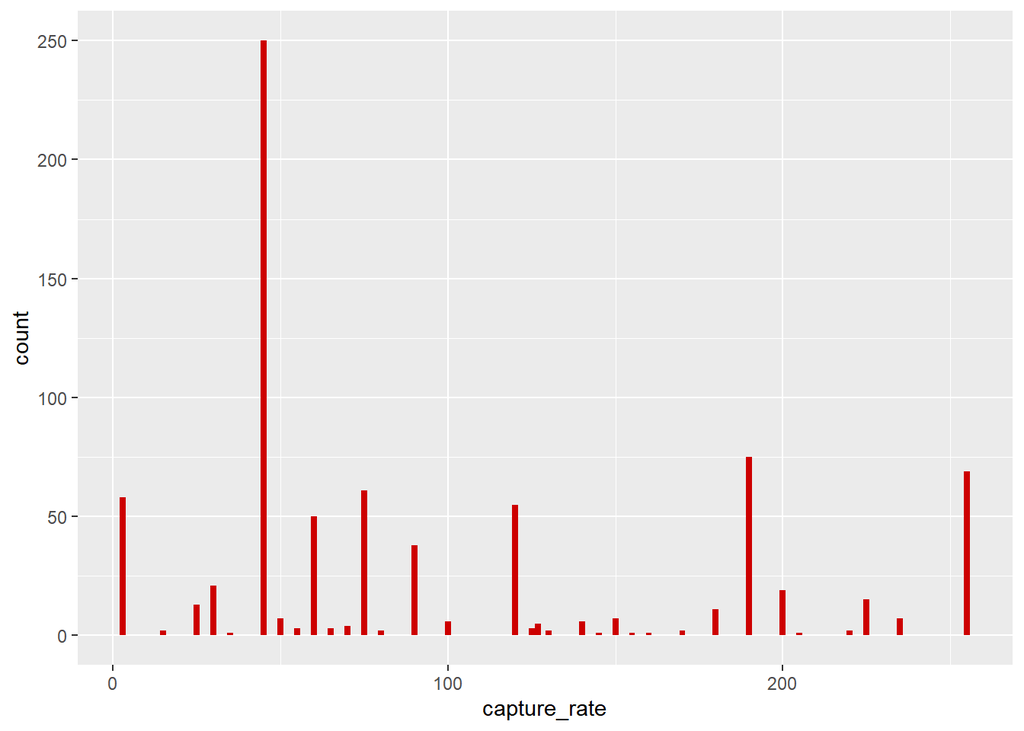

```r
# Distribution of capture rate
ggplot(pokemon_data, aes(capture_rate)) +
  geom_bar(fill='red3')
```

The possible values of `capture_rate` range from 0 to 255 and the `capture_rate` of the Pokemon in our data appears to range from 3 to 255. There is also a peak at about 45, meaning the most common capture rate for a Pokemon in our data is 45.

### Generation

The data contains 7 different generations of Pokemon. The generations contain Pokemon from each of the 7 generations of Pokemon games. This poses the question of whether there are specific generations that have higher capture rates overall than any other generations.

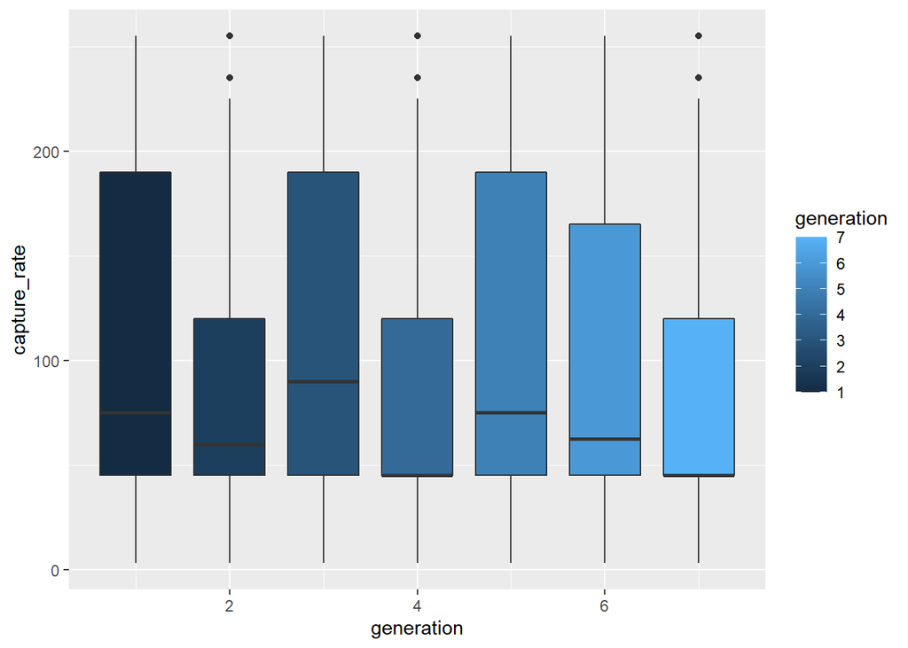

```r
# Boxplot of generation vs. capture rate
ggplot(pokemon, aes(x=generation, y=capture_rate, group=generation)) +
  geom_boxplot(aes(fill = generation))
```

### Legendary Status

Legendary Pokemon are especially powerful Pokemon that players rarely encounter. From this definition, it seems likely that it would be harder to capture a Pokemon that is legendary than one that is not.

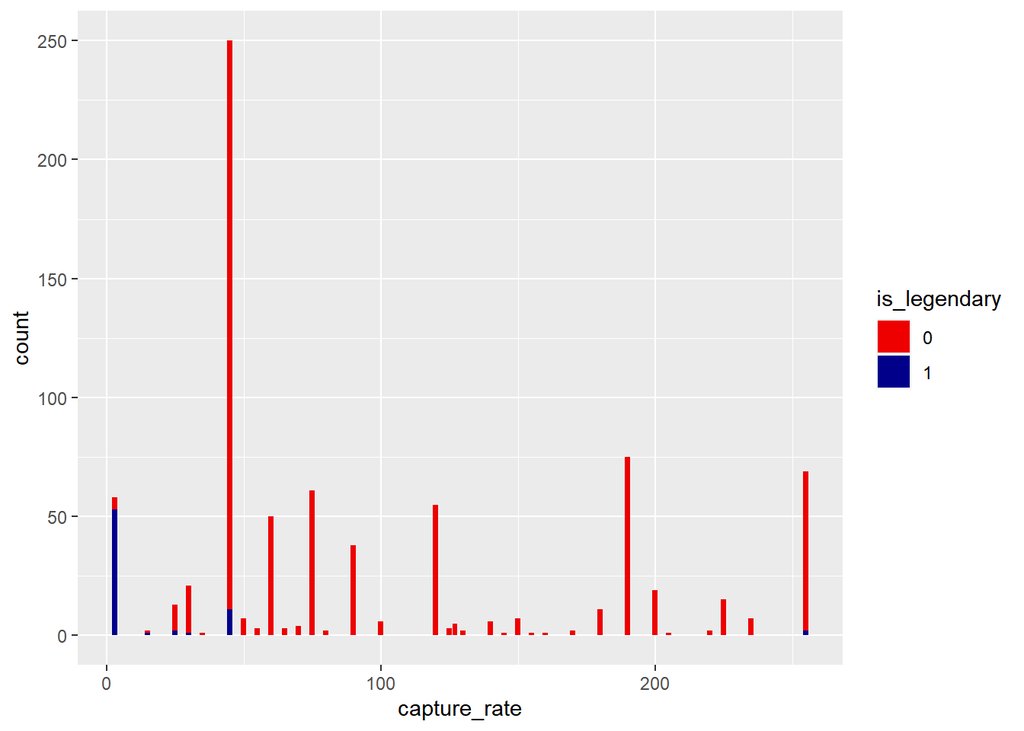

```r
ggplot(pokemon_data, aes(capture_rate)) +
  geom_bar(aes(fill = is_legendary)) +
  scale_fill_manual(values = c('red2', 'blue4'))
```

### Correlation Plot

Now, let’s explore the overall relationships between all of the continuous, non-missing variables using a correlation plot.

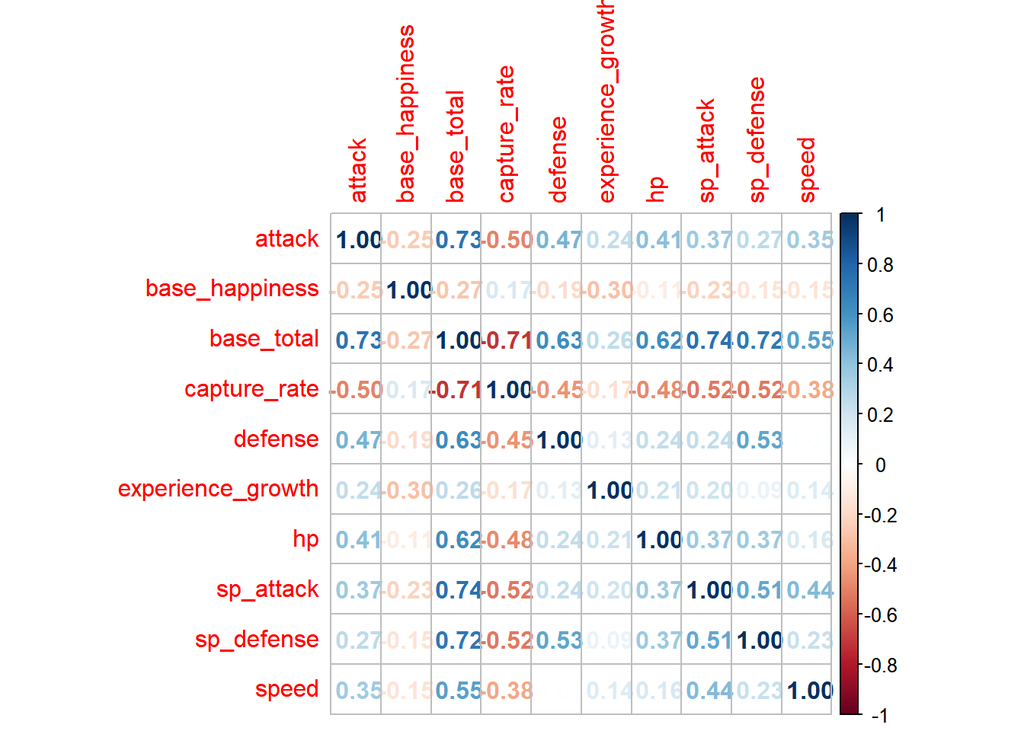

```r
# Selecting only numeric values
pokemon_numeric <- pokemon_data %>%
  select_if(is.numeric)
# Taking out variables with missing values as they will return NA
pokemon_numeric <- pokemon_numeric[, !names(pokemon_numeric) %in% c("height_m", "weight_kg", "percentage_male")]

# Correlation matrix
pokemon_cor <- cor(pokemon_numeric)

# Visualization of correlation matrix
pokemon_corrplot <- corrplot(pokemon_cor, method = "number")
```

One relationship that stands out is the relatively strong negative correlation between `base_total` and `capture_rate` (-0.71), which indicates that it may be useful to use `base_total` in our analysis rather than the six individual battle statistics (we cannot use all of them because the battle statistics add up to the exact `base_total`). This relationship implies that, as a Pokemon has a higher total of battle statistics, it becomes more difficult to capture them (lower `capture_rate`).

Another apparent relationship is that all six battle statistics are moderately positively correlated with `base_total` and moderately negatively correlated with `capture_rate`. This implies that, as the battle statistics increase, so does their total, which makes sense as they add up to the `base_total`. Also, as the six battle statistics increase, the Pokemon becomes more difficult to capture (lower `capture_rate`). Since the battle statistics have a similar relationship with `capture_rate` as `base_total`, this further justifies using only `base_total` rather than the six individual battle statistics.

# Setting up for the Models

It’s time to start fitting models to our data to see if we really can predict the capture rate of a Pokemon based on the predictors we have. However, we first have to set up our data by splitting it, creating the recipe, and creating folds for k-fold cross validation.

## Data Split

```r
# Setting the seed for reproducibility
set.seed(0124)

# Splitting the data (70/30 split, stratify on capture rate)
pokemon_split <- initial_split(pokemon_data, prop = 0.7, strata = capture_rate)
pokemon_train <- training(pokemon_split)
pokemon_test <- testing(pokemon_split)
```

Before we move on, we should verify that the data split correctly.

```r
nrow(pokemon_train)/nrow(pokemon_data)
```

```
## [1] 0.6978777
```

```r
nrow(pokemon_test)/nrow(pokemon_data)
```

```
## [1] 0.3021223
```

The training set has about 70% of the data and the testing set has about 30% of the data. So, the data was split correctly between the training and testing sets.

## Recipe Creation

Throughout our analysis, we will be using essentially the same predictors, conditions, and outcome. So, we will create one universal recipe to use for all of our models (and slightly adjust this recipe if needed). Each model will take this recipe and work with it using the methods associated with that model.

We will be using the same 14 predictors: `base_total`, `base_happiness`, `experience_growth`, `height_m`, `percentage_male`, `weight_kg`, `type1`, `generation`, `is_legendary`, `has_sturdy`, `has_swift_swim`, `has_keen_eye`, `has_chlorophyll`, and `has_levitate`. As mentioned in the exploratory data analysis, it would be best to use `base_total` instead of the individual six battle statistics because it has a higher negative correlation with the outcome and also acts as a summary of each Pokemon’s six battle statistics.

In order to deal with missingness, we will impute the missing data in `percentage_male`, `height_m`, and `weight_kg` using a linear regression of all of the other predictors in the recipe.

Since `type1` has 18 types, we will prioritize the types made up of the most Pokemon and group the rest of the Pokemon into type ‘Other’.

We will make `type1`, `generation`, `is_legendary`, `has_sturdy`, `has_swift_swim`, `has_keen_eye`, `has_chlorophyll`, and `has_levitate` into dummy variables because they are categorical and not continous.

Finally, we normalize our variables by centering and scaling.

```r
# Creating recipe
pokemon_recipe <- recipe(capture_rate ~ base_total + base_happiness + experience_growth + height_m + percentage_male + weight_kg + type1 + generation + is_legendary + has_sturdy + has_swift_swim + has_keen_eye + has_chlorophyll + has_levitate, data = pokemon_train) %>%
  # imputing percentage male
  step_impute_linear(percentage_male, impute_with = imp_vars(base_total, base_happiness, experience_growth, type1, generation, is_legendary, has_sturdy, has_swift_swim, has_keen_eye, has_chlorophyll, has_levitate)) %>%
  # imputing height
  step_impute_linear(height_m, impute_with = imp_vars(base_total, base_happiness, experience_growth, type1, generation, is_legendary, has_sturdy, has_swift_swim, has_keen_eye, has_chlorophyll, has_levitate)) %>%
  # imputing weight
  step_impute_linear(weight_kg, impute_with = imp_vars(base_total, base_happiness, experience_growth, type1, generation, is_legendary, has_sturdy, has_swift_swim, has_keen_eye, has_chlorophyll, has_levitate)) %>%
  # Only prioritizing top types of Pokemon
  step_other(type1) %>%
  # dummy coding nominal variables
  step_dummy(generation, is_legendary, type1, has_sturdy, has_swift_swim, has_keen_eye, has_chlorophyll, has_levitate) %>%
  # normalizing
  step_center(all_predictors()) %>%
  step_scale(all_predictors())
```

## K-Fold Cross Validation

```r
# Creating folds
pokemon_folds <- vfold_cv(pokemon_train, v = 10, strata = capture_rate)
```

# Model Building

## Fitting the models

For each of the models, you must conduct these steps to fit them:

1. Set up the model by specifying the model you wish to fit, the parameters you want to tune, the engine the model comes from, and the mode (regression or classification) if necessary.
2. Set up the workflow for the model and add the model and the recipe.
3. Create a tuning grid to specify the ranges of the parameters you wish to tune as well as how many levels of each.
4. Tune the model and specify the workflow, k-fold cross validation folds, and the tuning grid for our chosen parameters to tune.
5. Save the tuned models to an RDS file to avoid rerunning the model. Make sure to load back in the saved files.
6. Select the best tuned parameters for the model (based on RMSE), adjust the model workflow to include that version of the model, and fit the model with the best tuned parameters to the folds. Make sure to save the final fit.
7. Load in each of the best models and collect the RMSE’s of each of the best model fits for comparison with one another.

# Model Results

# Results of the Best Model

```r
# Fitting to the training data
best_rf_train <- select_best(rf_tuned)
rf_final_workflow_train <- finalize_workflow(rf_workflow, best_rf)
rf_final_fit_train <- fit(rf_final_workflow, data = pokemon_train)

write_rds(rf_final_fit, file = "rf_final_train.rds")
```

[output not shown]

```r
# Indicating the desired metric
pokemon_metric <- metric_set(rmse)

# Creating the predicted vs. actual value tibble
pokemon_tibble <- predict(rf_final_fit, new_data = pokemon_test %>% select(-capture_rate))
pokemon_tibble <- bind_cols(pokemon_tibble, pokemon_test %>% select(capture_rate))

# Collecting the rmse of the model on the testing data
pokemon_tibble_metrics <- pokemon_metric(pokemon_tibble, truth = capture_rate, estimate = .pred)
pokemon_tibble_metrics
```

[output not shown]